# Sentiment Analysis_Airlinedata_BhargaviRao

##### Objective

A sentiment analysis job about the problems of each major U.S. airline. The twitter data sentiments are classed as positive, negative, and neutral .

###### Import the necessary libraries

```python
import numpy as np
from sklearn.linear_model import LinearRegression
import pandas as pd
import seaborn as sns
import matplotlib.pyplot as plt# matplotlib.pyplot plots data
%matplotlib inline
from sklearn.model_selection import train_test_split
import missingno as msno
import warnings
pd.options.display.max_columns = None
pd.options.display.max_rows = None
warnings.filterwarnings("ignore")
pd.options.display.float_format = '{:,.2f}'.format
```

```python
# Import necessary libraries.
import re, string, unicodedata
import pandas as pd
import nltk

# Natural language processing tool-kit
nltk.download('punkt')
nltk.download('stopwords')
nltk.download('wordnet')


import contractions
from bs4 import BeautifulSoup                 # Beautiful soup is a parsing library that can use different parsers.
from nltk import word_tokenize, sent_tokenize
from nltk.corpus import stopwords, wordnet    # Stopwords, and wordnet corpus
from nltk.stem import LancasterStemmer, WordNetLemmatizer
```

```python
# install and import necessary libraries.

#!pip install contractions

import re, string, unicodedata                          # Import Regex, string and unicodedata.
import contractions                                     # Import contractions library.
from bs4 import BeautifulSoup                           # Import BeautifulSoup.

import numpy as np                                      # Import numpy.
import pandas as pd                                     # Import pandas.
import nltk                                             # Import Natural Language Tool-Kit.

nltk.download('stopwords')                              # Download Stopwords.
nltk.download('punkt')
nltk.download('wordnet')

from nltk.corpus import stopwords                       # Import stopwords.
from nltk.tokenize import word_tokenize, sent_tokenize  # Import Tokenizer.
from nltk.stem.wordnet import WordNetLemmatizer         # Import Lemmatizer.
```

Read the tweet data from the Tweets CSV

```python
data1=pd.read_csv('Tweets.csv')
```

```python
data1.head()
```

|  | tweet_id | airline_sentiment | airline_sentiment_confidence | negativereason | negativereason_confidence | airline | airline_sentiment_gold | name | negativereason_gold | retweet_count | text | tweet_coord | tweet_created | tweet_location | user_timezone |
| --- | --- | --- | --- | --- | --- | --- | --- | --- | --- | --- | --- | --- | --- | --- | --- |
| 0 | 570306133677760513 | neutral | 1.00 | NaN | nan | Virgin America | NaN | cairdin | NaN | 0 | @VirginAmerica What @dhepburn said. | NaN | 2015-02-24 11:35:52 -0800 | NaN | Eastern Time (US & Canada) |
| 1 | 570301130888122368 | positive | 0.35 | NaN | 0.00 | Virgin America | NaN | jnardino | NaN | 0 | @VirginAmerica plus you've added commercials t... | NaN | 2015-02-24 11:15:59 -0800 | NaN | Pacific Time (US & Canada) |
| 2 | 570301083672813571 | neutral | 0.68 | NaN | nan | Virgin America | NaN | yvonnalynn | NaN | 0 | @VirginAmerica I didn't today... Must mean I n... | NaN | 2015-02-24 11:15:48 -0800 | Lets Play | Central Time (US & Canada) |
| 3 | 570301031407624196 | negative | 1.00 | Bad Flight | 0.70 | Virgin America | NaN | jnardino | NaN | 0 | @VirginAmerica it's really aggressive to blast... | NaN | 2015-02-24 11:15:36 -0800 | NaN | Pacific Time (US & Canada) |
| 4 | 570300817074462722 | negative | 1.00 | Can't Tell | 1.00 | Virgin America | NaN | jnardino | NaN | 0 | @VirginAmerica and it's a really big bad thing... | NaN | 2015-02-24 11:14:45 -0800 | NaN | Pacific Time (US & Canada) |

```python
def basic_checks(df):

    print('='*50)
    print('Shape of the dataframe is: \n',df.shape)
    print('='*50)
    print('Basic stats for the data: \n',df.describe())
    print('='*50)
    print('Data type and info :')
    print(df.info())
    print('='*50)
    print('Missing value information : \n',df.isnull().any())
    print('='*50)
    print('Sum of missing values if any : \n',df.isnull().sum())
```

```python
basic_checks(data1)
```

```
==================================================
Shape of the dataframe is:
 (14640, 15)
==================================================
Basic stats for the data:
                         tweet_id  airline_sentiment_confidence  \
count                  14,640.00                     14,640.00
mean  569,218,351,767,382,528.00                          0.90
std       779,111,158,481,836.75                          0.16
min   567,588,278,875,213,824.00                          0.34
25%   568,559,178,101,439,488.00                          0.69
50%   569,477,857,923,110,912.00                          1.00
75%   569,890,473,289,000,960.00                          1.00
max   570,310,600,460,525,568.00                          1.00

       negativereason_confidence  retweet_count
count                  10,522.00      14,640.00
mean                        0.64           0.08
std                         0.33           0.75
min                         0.00           0.00
25%                         0.36           0.00
50%                         0.67           0.00
75%                         1.00           0.00
max                         1.00          44.00
==================================================
Data type and info :
<class 'pandas.core.frame.DataFrame'>
RangeIndex: 14640 entries, 0 to 14639
Data columns (total 15 columns):
tweet_id                        14640 non-null int64
airline_sentiment               14640 non-null object
airline_sentiment_confidence    14640 non-null float64
negativereason                  9178 non-null object
negativereason_confidence       10522 non-null float64
airline                         14640 non-null object
airline_sentiment_gold          40 non-null object
name                            14640 non-null object
negativereason_gold             32 non-null object
retweet_count                   14640 non-null int64
text                            14640 non-null object
```

[output cut: 28 more lines]

```
airline_sentiment                   0
airline_sentiment_confidence        0
negativereason                   5462
negativereason_confidence        4118
airline                             0
airline_sentiment_gold          14600
name                                0
negativereason_gold             14608
retweet_count                       0
text                                0
tweet_coord                     13621
tweet_created                       0
tweet_location                   4733
user_timezone                    4820
dtype: int64
```

###### Exploratory Data Analysis

Group by Airline and the Sentiment

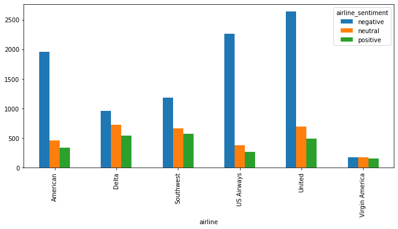

```python
data1.groupby(['airline','airline_sentiment']).size().unstack().plot(kind='bar',figsize=(11, 5))
```

Group by Sentiment - value counts and bar plot

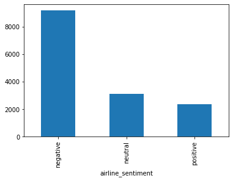

```python
data1.groupby('airline_sentiment').size().plot(kind='bar')
```

```python
data1['airline_sentiment'].value_counts()
```

```
negative    9178
neutral     3099
positive    2363
Name: airline_sentiment, dtype: int64
```

```python
round(data1.airline_sentiment.value_counts(normalize=True)*100,2)
```

```
negative   62.69
neutral    21.17
positive   16.14
Name: airline_sentiment, dtype: float64
```

###### Number of reviews by Airlines

```
Total number of tweets for each airline
  airline
United            3822
US Airways        2913
American          2759
Southwest         2420
Delta             2222
Virgin America     504
Name: airline_sentiment, dtype: int64
```

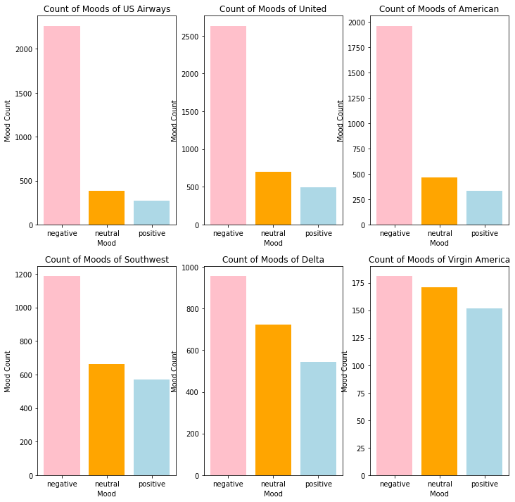

```python
print("Total number of tweets for each airline \n ",data1.groupby('airline')['airline_sentiment'].count().sort_values(ascending=False))
airlines= ['US Airways','United','American','Southwest','Delta','Virgin America']
plt.figure(1,figsize=(12, 12))
for i in airlines:
    indices= airlines.index(i)
    plt.subplot(2,3,indices+1)
    new_df=data1[data1['airline']==i]
    count=new_df['airline_sentiment'].value_counts()
    Index = [1,2,3]
    plt.bar(Index,count, color=['pink', 'orange', 'lightblue'])
    plt.xticks(Index,['negative','neutral','positive'])
    plt.ylabel('Mood Count')
    plt.xlabel('Mood')
    plt.title('Count of Moods of '+i)
```

###### Sentiment Word Clouds - Negative and positive

```python
from wordcloud import WordCloud,STOPWORDS
```

###### Negative Sentiment

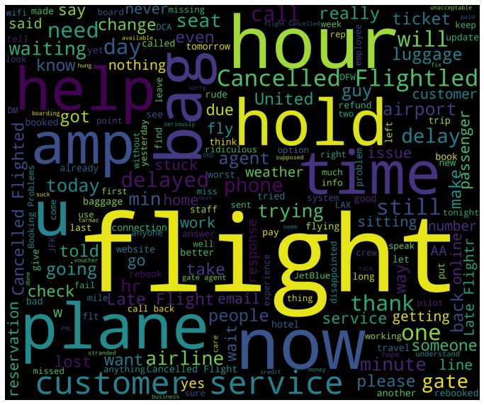

```python
new_df=data1[data1['airline_sentiment']=='negative']
words = ' '.join(new_df['text'])
cleaned_word = " ".join([word for word in words.split()
                            if 'http' not in word
                                and not word.startswith('@')
                                and word != 'RT'
                            ])
wordcloud = WordCloud(stopwords=STOPWORDS,
                      background_color='black',
                      width=3000,
                      height=2500
                     ).generate(cleaned_word)
plt.figure(1,figsize=(12, 12))
plt.imshow(wordcloud)
plt.axis('off')
plt.show()
```

###### Positive Sentiment

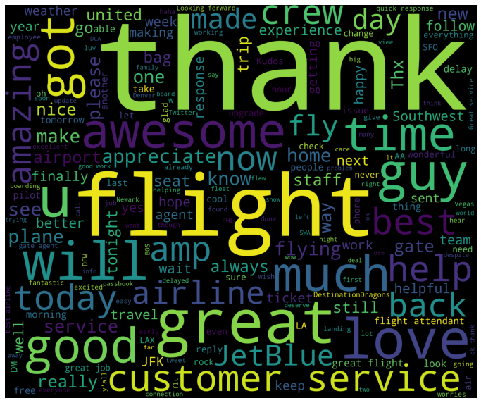

```python
new_df=data1[data1['airline_sentiment']=='positive']
words = ' '.join(new_df['text'])
cleaned_word = " ".join([word for word in words.split()
                            if 'http' not in word
                                and not word.startswith('@')
                                and word != 'RT'
                            ])
wordcloud = WordCloud(stopwords=STOPWORDS,
                      background_color='black',
                      width=3000,
                      height=2500
                     ).generate(cleaned_word)
plt.figure(1,figsize=(12, 12))
plt.imshow(wordcloud)
plt.axis('off')
plt.show()
```

###### Reasons for negative reviews

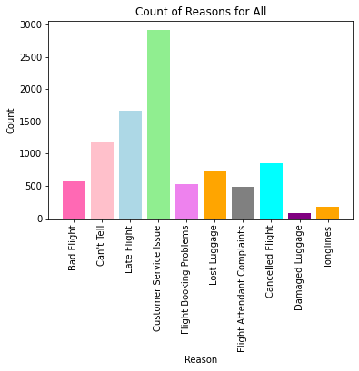

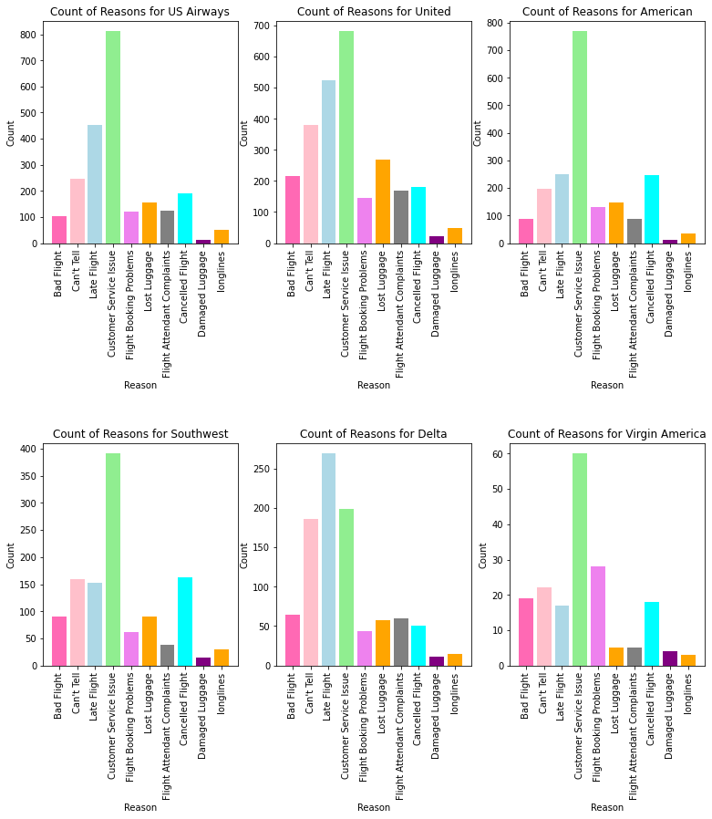

```python
data1['negativereason'].nunique()

NR_Count=dict(data1['negativereason'].value_counts(sort=False))
def NR_Count(Airline):
    if Airline=='All':
        a=data1
    else:
        a=data1[data1['airline']==Airline]
    count=dict(a['negativereason'].value_counts())
    Unique_reason=list(data1['negativereason'].unique())
    Unique_reason=[x for x in Unique_reason if str(x) != 'nan']
    Reason_frame=pd.DataFrame({'Reasons':Unique_reason})
    Reason_frame['count']=Reason_frame['Reasons'].apply(lambda x: count[x])
    return Reason_frame
def plot_reason(Airline):

    a=NR_Count(Airline)
    count=a['count']
    Index = range(1,(len(a)+1))
    plt.bar(Index,count, color=['hotpink','pink','lightblue','lightgreen','violet','orange','gray','cyan','purple','orange'])
    plt.xticks(Index,a['Reasons'],rotation=90)
    plt.ylabel('Count')
    plt.xlabel('Reason')
    plt.title('Count of Reasons for '+Airline)

plot_reason('All')
plt.figure(2,figsize=(13, 13))
for i in airlines:
    indices= airlines.index(i)
    plt.subplot(2,3,indices+1)
    plt.subplots_adjust(hspace=0.9)
    plot_reason(i)
```

###### EDA - part 2

**Dropping unnecessary columns**

`Only extracting the useful columns for the sentiment analysis and discarding the remainder of the columns`

1.From the original dataset we drop all columns except for Airline_sentiment and text 2.There is no missing values in this data

**Preprocessing of the text data**

`We go through the following steps to pre process the text data :`

1. Remove HTML tags - remove '<.*?>'
2. Replace contractions - expand any contractions
3. Remove numbers
4. Tokenization - tokenize the text
5. Remove stop words - form a list of stop words and remove those from the text
6. Lemmatize the data
7. Join the words in the list of words

```python
data = data1[['airline_sentiment', 'text']]
```

```python
data.head()
```

|  | airline_sentiment | text |
| --- | --- | --- |
| 0 | neutral | @VirginAmerica What @dhepburn said. |
| 1 | positive | @VirginAmerica plus you've added commercials t... |
| 2 | neutral | @VirginAmerica I didn't today... Must mean I n... |
| 3 | negative | @VirginAmerica it's really aggressive to blast... |
| 4 | negative | @VirginAmerica and it's a really big bad thing... |

```python
basic_checks(data)
```

```
==================================================
Shape of the dataframe is:
 (14640, 2)
==================================================
Basic stats for the data:
        airline_sentiment            text
count              14640           14640
unique                 3           14427
top             negative  @united thanks
freq                9178               6
==================================================
Data type and info :
<class 'pandas.core.frame.DataFrame'>
RangeIndex: 14640 entries, 0 to 14639
Data columns (total 2 columns):
airline_sentiment    14640 non-null object
text                 14640 non-null object
dtypes: object(2)
memory usage: 228.9+ KB
None
==================================================
Missing value information :
 airline_sentiment    False
text                 False
dtype: bool
==================================================
Sum of missing values if any :
 airline_sentiment    0
text                 0
dtype: int64
```

###### Missing values

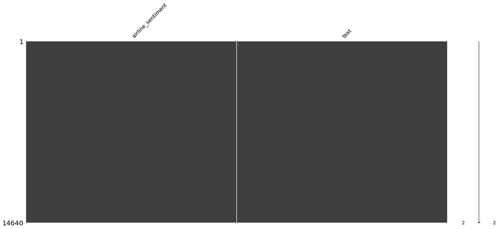

```python
msno.matrix(data)
```

```python
data.head()
```

|  | airline_sentiment | text |
| --- | --- | --- |
| 0 | neutral | @VirginAmerica What @dhepburn said. |
| 1 | positive | @VirginAmerica plus you've added commercials t... |
| 2 | neutral | @VirginAmerica I didn't today... Must mean I n... |
| 3 | negative | @VirginAmerica it's really aggressive to blast... |
| 4 | negative | @VirginAmerica and it's a really big bad thing... |

```python
data.columns
```

```
Index(['airline_sentiment', 'text'], dtype='object')
```

Remove Contractions

```python
def replace_contractions(text):
    """Replace contractions in string of text"""
    return contractions.fix(text)

data['text'] = data['text'].apply(lambda x: replace_contractions(x))
data.head()
```

|  | airline_sentiment | text |
| --- | --- | --- |
| 0 | neutral | @VirginAmerica What @dhepburn said. |
| 1 | positive | @VirginAmerica plus you have added commercials... |
| 2 | neutral | @VirginAmerica I did not today... Must mean I ... |
| 3 | negative | @VirginAmerica it is really aggressive to blas... |
| 4 | negative | @VirginAmerica and it is a really big bad thin... |

Remove numbers

```python
def remove_numbers(text):
  text = re.sub(r'\d+', '', text)
  return text

data['text'] = data['text'].apply(lambda x: remove_numbers(x))
data.head()
```

|  | airline_sentiment | text |
| --- | --- | --- |
| 0 | neutral | @VirginAmerica What @dhepburn said. |
| 1 | positive | @VirginAmerica plus you have added commercials... |
| 2 | neutral | @VirginAmerica I did not today... Must mean I ... |
| 3 | negative | @VirginAmerica it is really aggressive to blas... |
| 4 | negative | @VirginAmerica and it is a really big bad thin... |

Remove HTML tags

```python
import re

TAG_RE = re.compile('<.*?>')

def remove_tags(text):
    return TAG_RE.sub('', text)

data['text']=data['text'].apply(lambda x:remove_tags(x))
data.head()
```

|  | airline_sentiment | text |
| --- | --- | --- |
| 0 | neutral | @VirginAmerica What @dhepburn said. |
| 1 | positive | @VirginAmerica plus you have added commercials... |
| 2 | neutral | @VirginAmerica I did not today... Must mean I ... |
| 3 | negative | @VirginAmerica it is really aggressive to blas... |
| 4 | negative | @VirginAmerica and it is a really big bad thin... |

Tokenization

```python
data['text'] = data.apply(lambda row: nltk.word_tokenize(row['text']), axis=1) # Tokenization of data
```

```python
data.head()
```

|  | airline_sentiment | text |
| --- | --- | --- |
| 0 | neutral | [@, VirginAmerica, What, @, dhepburn, said, .] |
| 1 | positive | [@, VirginAmerica, plus, you, have, added, com... |
| 2 | neutral | [@, VirginAmerica, I, did, not, today, ..., Mu... |
| 3 | negative | [@, VirginAmerica, it, is, really, aggressive,... |
| 4 | negative | [@, VirginAmerica, and, it, is, a, really, big... |

Stopwords

```python
stopwords = stopwords.words('english')

customlist = ['not', "couldn't", 'didn', "didn't", 'doesn', "doesn't", 'hadn', "hadn't", 'hasn',
        "hasn't", 'haven', "haven't", 'isn', "isn't", 'ma', 'mightn', "mightn't", 'mustn',
        "mustn't", 'needn', "needn't", 'shan', "shan't", 'shouldn', "shouldn't", 'wasn',
        "wasn't", 'weren', "weren't", 'won', "won't", 'wouldn', "wouldn't"]

# Set custom stop-word's list as not, couldn't etc. words matter in Sentiment, so not removing them from original data.

stopwords = list(set(stopwords) - set(customlist))
```

Lemmatize

```python
lemmatizer = WordNetLemmatizer()

def remove_non_ascii(words):
    """Remove non-ASCII characters from list of tokenized words"""
    new_words = []
    for word in words:
        new_word = unicodedata.normalize('NFKD', word).encode('ascii', 'ignore').decode('utf-8', 'ignore')
        new_words.append(new_word)
    return new_words
```

```python
def to_lowercase(words):
    """Convert all characters to lowercase from list of tokenized words"""
    new_words = []
    for word in words:
        new_word = word.lower()
        new_words.append(new_word)
    return new_words
```

```python
def remove_punctuation(words):
    """Remove punctuation from list of tokenized words"""
    new_words = []
    for word in words:
        new_word = re.sub(r'[^\w\s]', '', word)
        if new_word != '':
            new_words.append(new_word)
    return new_words
```

```python
def remove_stopwords(words):
    """Remove stop words from list of tokenized words"""
    new_words = []
    for word in words:
        if word not in stopwords:
            new_words.append(word)
    return new_words
```

```python
def lemmatize_list(words):
    new_words = []
    for word in words:
      new_words.append(lemmatizer.lemmatize(word, pos='v'))
    return new_words
```

```python
def normalize(words):
    words = remove_non_ascii(words)
    words = to_lowercase(words)
    words = remove_punctuation(words)
    words = remove_stopwords(words)
    words = lemmatize_list(words)
    return ' '.join(words)

data['text'] = data.apply(lambda row: normalize(row['text']), axis=1)
data.head()
```

|  | airline_sentiment | text |
| --- | --- | --- |
| 0 | neutral | virginamerica dhepburn say |
| 1 | positive | virginamerica plus add commercials experience ... |
| 2 | neutral | virginamerica not today must mean need take an... |
| 3 | negative | virginamerica really aggressive blast obnoxiou... |
| 4 | negative | virginamerica really big bad thing |

```python
words_list=[each.split(" ") for each in data['text']]

#words_list # list of lists

import itertools
corpus=set(itertools.chain(*words_list))
len(corpus)
```

```
12073
```

###### Applying Count and TFidf Vectorizers

The data above is ready to start apply the count/tf idf vectorizers .The following will be the approach to apply the vectorization and classify the data 1. Apply the count/tf idf vectorizers 2. Generate an array of the vector object 3. Split the training and testing from the main dataset 4. Apply a classification alogorithm - Random Forest/Extra Trees Regressor 5. Print the accuracy 6. Print the 3x3 confusion matrix - We have 3 classes for Sentiment ,positive ,negative and neutral.

###### Count Vectorization

```python
from sklearn.feature_extraction.text import CountVectorizer

vectorizer = CountVectorizer(max_features=1000)                # Keep only 1000 features as number of features will increase the processing time.
data_features = vectorizer.fit_transform(data['text'])

data_features = data_features.toarray()
```

```python
data_features.shape
```

```
(14640, 1000)
```

```python
data['sentiment']=data['airline_sentiment'].apply(lambda x: 0 if x=='negative' else  (2 if x=='neutral' else 1))
```

```python
data['sentiment'].value_counts()
```

```
0    9178
2    3099
1    2363
Name: sentiment, dtype: int64
```

```python
data.drop(['airline_sentiment'],axis=1,inplace=True)
```

```python
data.head()
```

|  | text | sentiment |
| --- | --- | --- |
| 0 | virginamerica dhepburn say | 2 |
| 1 | virginamerica plus add commercials experience ... | 1 |
| 2 | virginamerica not today must mean need take an... | 2 |
| 3 | virginamerica really aggressive blast obnoxiou... | 0 |
| 4 | virginamerica really big bad thing | 0 |

###### Split the data into training and testing sets

```python
labels=data['sentiment']
```

```python
labels.dtype
```

```
dtype('int64')
```

```python
from sklearn.model_selection import train_test_split

X_train, X_test, y_train, y_test = train_test_split(data_features, labels,test_size=0.2, random_state=42)
```

###### Count Vectorizer - RF Model

```python
from sklearn.ensemble import RandomForestClassifier
from sklearn.model_selection import cross_val_score

forest = RandomForestClassifier(n_estimators=500, n_jobs=4)

forest = forest.fit(X_train, y_train)

print(forest)
```

[output not shown]

```python
model_score=forest.score(X_test,y_test)
print('RandomForest Test Accuracy Score :',model_score)
```

```
RandomForest Test Accuracy Score : 0.7742486338797814
```

```python
result_rf = forest.predict(X_test)
```

###### Count Vectorizer - ExtraTrees Regressor

```python
from sklearn.ensemble import ExtraTreesClassifier

xtrees = ExtraTreesClassifier(n_jobs=4,n_estimators=500)

xtrees = xtrees.fit(X_train, y_train)

print(xtrees)
```

[output not shown]

```python
model_score=xtrees.score(X_test,y_test)
print('Xtra Trees Test Accuracy Score :',model_score)
```

```
Xtra Trees Test Accuracy Score : 0.7851775956284153
```

```python
result_xt = xtrees.predict(X_test)
```

###### RF model - Confusion Matrix

```python
print(metrics.classification_report(y_test,result_rf))
```

```
              precision    recall  f1-score   support

           0       0.84      0.89      0.86      1889
           1       0.73      0.62      0.67       459
           2       0.57      0.52      0.55       580

    accuracy                           0.77      2928
   macro avg       0.71      0.68      0.69      2928
weighted avg       0.77      0.77      0.77      2928
```

```
[[1678   56  155]
 [ 100  286   73]
 [ 225   52  303]]
```

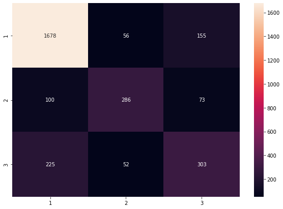

```python
from sklearn.metrics import confusion_matrix

conf_mat = confusion_matrix(y_test, result_rf)

print(conf_mat)

df_cm = pd.DataFrame(conf_mat, index = [i for i in "123"],
                  columns = [i for i in "123"])
plt.figure(figsize = (10,7))
sns.heatmap(df_cm, annot=True, fmt='g')
```

###### ExtraTrees-Confusion Matrix

```python
print(metrics.classification_report(y_test,result_xt))
```

```
              precision    recall  f1-score   support

           0       0.84      0.90      0.87      1889
           1       0.72      0.65      0.68       459
           2       0.61      0.51      0.55       580

    accuracy                           0.79      2928
   macro avg       0.72      0.69      0.70      2928
weighted avg       0.78      0.79      0.78      2928
```

```
[[1708   54  127]
 [  99  297   63]
 [ 225   61  294]]
```

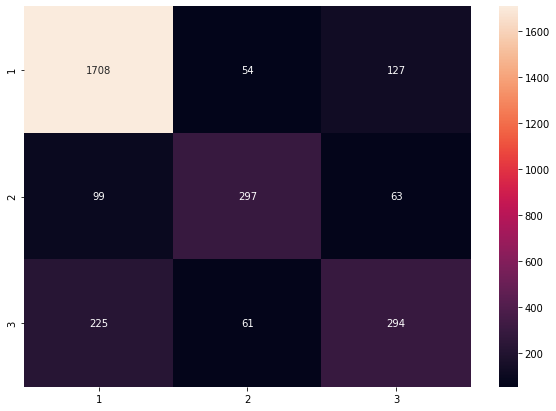

```python
conf_mat = confusion_matrix(y_test, result_xt)

print(conf_mat)

df_cm = pd.DataFrame(conf_mat, index = [i for i in "123"],
                  columns = [i for i in "123"])
plt.figure(figsize = (10,7))
sns.heatmap(df_cm, annot=True, fmt='g')
```

###### Tf- IDF vectorizer

```python
from sklearn.feature_extraction.text import TfidfVectorizer

vectorizer = TfidfVectorizer(max_features=1000)
data_features = vectorizer.fit_transform(data['text'])

data_features = data_features.toarray()

data_features.shape
```

```
(14640, 1000)
```

```python
# Using Random Forest to build model for the classification of reviews.

from sklearn.ensemble import RandomForestClassifier
from sklearn.model_selection import cross_val_score

import numpy as np

forestvect = RandomForestClassifier(n_estimators=500, n_jobs=-1)

forestvect = forestvect.fit(X_train, y_train)

print(forestvect)
```

```
RandomForestClassifier(n_estimators=500, n_jobs=-1)
```

```python
model_score=forestvect.score(X_test,y_test)
print('Random Forest - TFIDF Test Accuracy Score :',model_score)
```

```
Random Forest - TFIDF Test Accuracy Score : 0.774931693989071
```

```python
result_rfvect = forestvect.predict(X_test)
```

```python
print(metrics.classification_report(y_test,result_rfvect))
```

```
              precision    recall  f1-score   support

           0       0.83      0.90      0.86      1889
           1       0.72      0.62      0.67       459
           2       0.58      0.51      0.54       580

    accuracy                           0.77      2928
   macro avg       0.71      0.67      0.69      2928
weighted avg       0.77      0.77      0.77      2928
```

```
[[1691   54  144]
 [ 105  284   70]
 [ 232   54  294]]
```

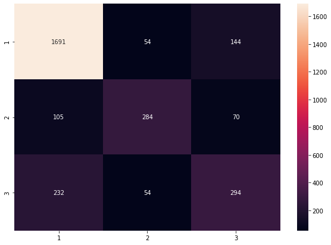

```python
conf_mat = confusion_matrix(y_test, result_rfvect)

print(conf_mat)

df_cm = pd.DataFrame(conf_mat, index = [i for i in "123"],
                  columns = [i for i in "123"])
plt.figure(figsize = (10,7))
sns.heatmap(df_cm, annot=True, fmt='g')
```

```python
xtrees_vect = ExtraTreesClassifier(n_jobs=4,n_estimators=500)

xtrees_vect = xtrees_vect.fit(X_train, y_train)

print(xtrees_vect)
```

```
ExtraTreesClassifier(n_estimators=500, n_jobs=4)
```

```python
model_score=xtrees_vect.score(X_test,y_test)
print('Extra Trees regressor - TFIDF Test Accuracy Score :',model_score)
```

```
Extra Trees regressor - TFIDF Test Accuracy Score : 0.7851775956284153
```

```python
result_xtreesvect = xtrees_vect.predict(X_test)
```

```python
print(metrics.classification_report(y_test,result_xtreesvect))
```

```
              precision    recall  f1-score   support

           0       0.84      0.91      0.87      1889
           1       0.73      0.64      0.68       459
           2       0.61      0.50      0.55       580

    accuracy                           0.79      2928
   macro avg       0.72      0.68      0.70      2928
weighted avg       0.77      0.79      0.78      2928
```

```
[[1715   51  123]
 [ 102  294   63]
 [ 230   60  290]]
```

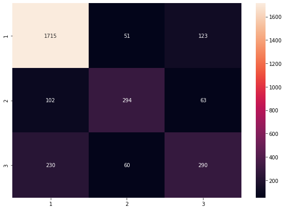

```python
conf_mat = confusion_matrix(y_test, result_xtreesvect)

print(conf_mat)

df_cm = pd.DataFrame(conf_mat, index = [i for i in "123"],
                  columns = [i for i in "123"])
plt.figure(figsize = (10,7))
sns.heatmap(df_cm, annot=True, fmt='g')
```

**Results - TF IDF & Count Vectorizer - Randome Forest vs Extra Trees Regressor**

`Count Vectorizer`

1. We visually compare the results of 2 of the classifiers that have given best results from a list of classifiers tried :RandomForest Classifier and the ExtraTrees Classifier
2. The accuracy is definitely better in the Extra Trees Regressor than in the Random Forest Regressor
3. The accuracy on the Test set is 79% in the Extra Trees Regressor while 77% accuracy in Random Forest Regressor
4. The confusion Matrix and the classification report show FP,TN,TP,FN values .Comparing these values we conclude that the Extra Trees Regressor is a better model than Random Forest Classifier as the recall and f1 scores are better in Extra Trees regressor

`Business Insights`

True Negative (observed=0,predicted=0)

False Positive (observed=0,predicted=1)

True Negative (observed=0,predicted=0)

False Negative(observed=1,predicted=0)

The metric of main interest should in my opinion here be Accuracy as we are trying to gauge the number of customers that left a negative tweet and were recognized as a negative tweet and left a positive/neutral tweet and were right identified so .

True negatives and True positives here enable us in analyzing the customer behavior correctly

Although false positive and False negative numbers still have a significant impact on decision making ,identifying the reviews under the correct category is still of utmost importance.

**We can therefore conclude that the Extra Trees Regressor is a better model as opposed to Random Forest model in enabling to make better business decisions**

`N.B`

1. The exercise was tried with multiple classifiers and they aren't all listed here keeping in mind the motive of the exercise ,only the 2 best models were handpicked and compared for both Count and TF IDF vectorizers
2. The exercse was tested using just 2 classes instead of 1 and the accuracy seemed better in this case .However to retain the classes that were originally in the document we keep all 3 classes - positive negative and neutral